# [ijgis-revision]Theoretical predictability of check-in behavior

Thursday, May 21, 2015

**Note:**

```
This document shows the general workflow of the experiment, and it is in line with our revised paper.

This document provides more details about the experiment (the data, the code, etc.), while for more detailed discussions on the experimental results one should refer to the paper.
```

**Brief information for the paper:**

```
First submission date: 16.11.2014
Title: Assessing the Limits of Predictability in Location-based Social Networks - A Case Study of Foursquare
First decision date: 26.01.2015
-----------
Revision: Jan - May, 2015
-----------
Second submission: 21.05.2015
Title: Theoretical Predictability of Users Check-in Behaviour in Location-based Social Networks: An example of Foursquare
```

#### 0. Brief introduction to the paper:

- The **topic** of this paper is to investigate the predictability of check-in behavior in LBSN.

We further clarify our research topic by defining the two topic terms *check-in behavior* and *predictability*.

> Check-in behavior: the actions or mannerisms of mobile users reporting their whereabouts via a LBSN provider.

> Predictability: the degree to which a correct prediction of users check-in behaviour can be made based on the dataset, and it is quantified by an interval of upper and lower bounds with respect to the prediction precision of the dataset.

Hence, we are investigating the theoretical boundaries of prediction accurarcy when predicting a user’s check-in venue given some of his/her contextual information (e.g., time, space).

- The paper has two main **research goals**:
  - to explore the theoretical predicatability of check-in behavior in LBSN;
  - to provide useful insights for researchers with variation patterns of predictability.
- These two goals correspond to the two **research questions** in the research field of “predicting user’s whereabouts with LBSN”:
  - how to impartially evaluate an algorithm? (If the limitation/potential of a dataset is unknown, a single value of prediction accurarcy would not be as meaningful.)
  - how to efficiently improve an algorithm? (If the varition pattern of predictability is unknown, algorithm designers could have no clue towards improving their algorithms.)

#### 1. Dataset and preprocessing

The experimantal datasets are crawled from three cities in USA, namely Chicago, Los Angeles and New York City. The reason for choosing these three study sites is because users in these cities have high level of activity in both Foursquare and Twitter. (Foursquare only makes the check-ins that are published via Twitter public.)

The dataset looks as follows. Each point corresponds to a unique venue, with its size representing its check-in frequency. The first 6 rows in each dataset will also be provided after the map to show the structure of the datasets.

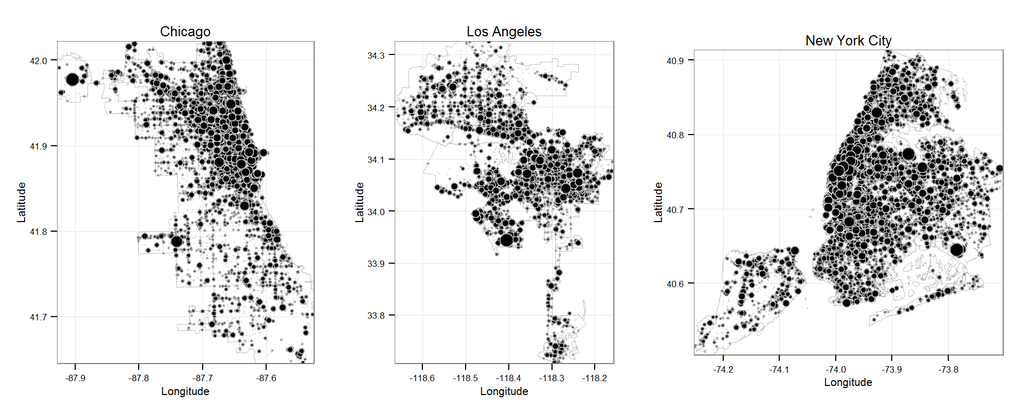

```
## [1] "Chicago"
```

```
##     gid  user_id                 venue_id   lat    lon
## 1 12035 10307561 4f18f769e4b040253fdf23fe 41.89 -87.63
## 2 12029  8706642 4ae4f48ff964a520aa9f21e3 41.96 -87.68
## 3 11995   242558 4fe0a8dbe5e80efd0706f5df 41.90 -87.68
## 4 11997  6060300 40b28c80f964a52017fc1ee3 41.93 -87.65
## 5 11998 18180252 4a4bd457f964a520c7ac1fe3 41.89 -87.62
## 6 11999  3426067 4a6bfd1ff964a52055d01fe3 41.92 -87.65
##                localtime            cate_l1       cate_l2   ZIP
## 1 2014-02-01 00:00:58-06     Nightlife Spot        Lounge 60654
## 2 2014-02-01 00:04:50-06 Travel & Transport Train Station 60613
## 3 2014-02-01 00:04:58-06     Nightlife Spot           Bar 60622
## 4 2014-02-01 00:05:36-06     Nightlife Spot      Dive Bar 60614
## 5 2014-02-01 00:06:17-06 Travel & Transport         Hotel 60601
## 6 2014-02-01 00:06:21-06     Nightlife Spot    Sports Bar 60614
```

```
## [1] "Los Angeles"
```

```
##    gid  user_id                 venue_id   lat    lon
## 1 9784  9799281 4de47a6cae60e7f3ac1fce45 33.79 -118.3
## 2 9786  5818603 4c943a08efecb713812fdd9d 34.05 -118.3
## 3 9787 22510532 529d57f011d2d47f636f0914 34.07 -118.5
## 4 9788  1257710 45dee120f964a5200f431fe3 34.09 -118.3
## 5 9789  2206577 45dee120f964a5200f431fe3 34.09 -118.3
## 6 9791   152513 4e08a44eae60a90eabd010e0 34.18 -118.4
##                localtime              cate_l1                cate_l2
## 1 2014-02-01 00:00:59-08            Residence         Home (private)
## 2 2014-02-01 00:01:05-08       Nightlife Spot              Nightclub
## 3 2014-02-01 00:01:18-08 College & University College Residence Hall
## 4 2014-02-01 00:02:38-08       Shop & Service   Gym / Fitness Center
## 5 2014-02-01 00:02:42-08       Shop & Service   Gym / Fitness Center
## 6 2014-02-01 00:03:45-08            Residence         Home (private)
##   Zip_Num
## 1   90710
## 2   90014
## 3   90024
## 4   90038
## 5   90038
## 6   91606
```

```
## [1] "New York City"
```

```
##     gid  user_id                 venue_id   lat    lon
## 1 19128  3094897 3fd66200f964a52035e41ee3 40.73 -73.99
## 2 19125 11399350 3fd66200f964a520e0e51ee3 40.72 -73.99
## 3 19121  6474596 51b91e37498e72946e18b8ef 40.58 -73.82
## 4 19122  2905627 49caa5a0f964a520d0581fe3 40.74 -73.98
## 5 19119  1137132 4e5e96dbd4c08cf7f58fe276 40.74 -73.99
## 6 19172 21018662 51814a7b498e2b4ffb2aff91 40.77 -73.99
##                localtime              cate_l1
## 1 2014-02-01 00:00:04-05 Arts & Entertainment
## 2 2014-02-01 00:01:28-05       Nightlife Spot
## 3 2014-02-01 00:01:52-05   Travel & Transport
## 4 2014-02-01 00:01:52-05       Nightlife Spot
## 5 2014-02-01 00:01:59-05       Nightlife Spot
## 6 2014-02-01 00:02:36-05            Residence
##                                    cate_l2 POSTAL
## 1                              Music Venue  10003
## 2                                      Bar  10012
## 3                                    Hotel  11693
## 4                               Sports Bar  10016
## 5                               Sports Bar  10010
## 6 Residential Building (Apartment / Condo)  10019
```

We find the dataset is large but sparse. More specifically, we find a truncated power law distribution w.r.t. the user contribution.

```r
# simulating
truncated.para = lapply(1:3,function(city.index){
    model = nls(ecdf~truncated.plfit.cdf(Frequency,x0,beta,ka),
        data=personal.stat.cdf[[city.index]],trace=TRUE,algorithm="port",
        start=list(x0=0,beta=1,ka=100),
        lower=c(x0=0,beta=1,ka=100),upper=c(x0=5,beta=3,ka=800))
    summary(model)$parameters[,1]

})
truncated.para = data.frame(do.call(rbind,truncated.para),"city"=city.guide$city)
```

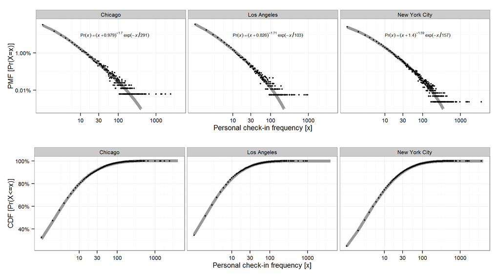

The fact that more than 90% users have less than 30 personal records (see the second subplot in the figure above) would make statistics questionable. There are basically two ways to deal with it:

- to filter the 90% users out;
- to aggregate the user by their similarity.

Both of them are very common practics. Here we adopt the second option because we want to leverage the entire potential of the dataset. The aggregation is done in the following steps:

- describe each user $u_{i}$ by a historical *visit vector*;
- compute *user similarity* from the cosine distance between their *visit vector*;
- use *k-means* to cluster/aggregate the user:
  - determine a suitable $k$ from the trend;
  - use the determined $k$ to perform aggregation.

```r
nr.cls.candidates = list(c(200,500,1000,2000,3000,4000,5000,6000),
                   c(200,500,1000,2000,3000,4000,5000,6000),
                   c(200,500,1000,2500,5000,7500,10000,12500,15000))
clusters.list = lapply(1:3,function(city.index){ # for each of the three datasets

    checkin = checkin.poly.list[[city.index]] # get the ith checkin dataset

    user.list.all = split(checkin,checkin$user_id)
    # create user vector
    counter.reset(); time=Sys.time();
    point.vectors = sapply(user.list.all,function(user){
        counter.print(500)
        table(user$cate_l2)
    })
    time.print(Sys.time(), time, paste("creating user vectors for city",
                                       city.index,"takes"))

    # now we should discuss how we decide the number of clusters.
    # It should be a compromise between the between_variances and
    # the records in each cluster. We should keep as much variance
    # as possible, while make sure there are still enough records
    # in each cluster for valid statistics.
    # ! computational heavy !
    nr.clusters = nr.cls.candidates[[city.index]]
    clusters = lapply(nr.clusters,function(i){
       time = Sys.time();
       clusters = kmeans(t(point.vectors),centers=i,iter.max = 1000)
       time.print(Sys.time(), time, "creating user clusters takes")

       pct.ss = clusters$betweenss / clusters$totss
       user.sizes = sapply(user.list.all,function(user){
           nrow(user)
       })
       agg.sizes = as.data.frame(xtabs(data=data.frame("size"=user.sizes,
                                                       "cls"=clusters$cluster),
                                       size~cls))

       list(clusters,pct.ss,agg.sizes)
    })
    # save the result out because it is quite heavy computation
    save(clusters,file=paste0("data/clusters_",city.index,".Rda"))

    clusters
})
```

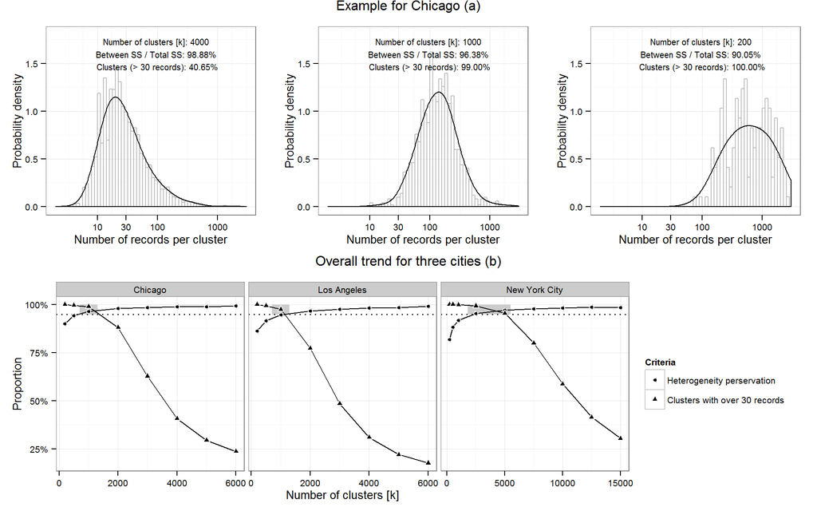

We decided *k* for the three cities are 1000, 1000 and 2500 respectively. The datasets are aggregated accordingly.

```r
# choose the number of clusters based the plotting result
nr.cls.final.id = c(3,3,4) # 1000, 1000, 2500
# user aggregation and respliting
user.list.ucls = lapply(1:3,function(city.index){
    counter.reset();
    checkin = checkin.poly.list[[city.index]]
    checkin$cluster.id = sapply(checkin$user_id,function(user){
        counter.print(4000)
        clusters.in.city = clusters.list[[city.index]]
        clusters.final = clusters.in.city[[nr.cls.final.id[city.index]]]
        clusters.final[[1]]$cluster[as.character(user)] # the cluster id for that user
    })
#     save(checkin,file=paste0("data/checkin.poly.cls_",city.index,".Rda"))
#     load(paste0("data/checkin.poly.cls_",city.index,".Rda"))
    split(checkin,checkin$cluster.id)
})
```

#### 2. Predictability (upper and lower bounds)

The upper bound of predictability is determined by Fano’s inequality which gives numerical relations between *propability of making error* and *entropy*. We use three types of context (temporal, spatial and spatiotemporal) to decide three groups of *conditional entropy*. Here temporal context is represented by the hour of check-in; spatial context is represented by the zip code region of check-in, and spatiotemporal is represented by both.

One point to add here is related with the small sample issue that oftentimes occur with LBSN dataset, especially when a contexutal condition is exerted. To deal with the small sample issue, some corrections must be made accordingly.

```r
##########################
# main function to decide predictability
get.predictability = function(data,cond.col,condition.name,prior.freq){

    freq.joint = get.freq.dataframe(data=data,"venue_id",cond.col,
                                    p.cond=T,p.joint=F)

    N = sum(freq.joint$Freq)
    L = length(unique(data$venue_id))

    in.condition = ddply(freq.joint, .(condition), function(i){
        n = sum(i$Freq)
        l = length(unique(i$venue_id))

        prior.freq = merge(x=i, y=prior.freq, by=c("obs"),all.x=T)
        prior.freq$p.adjusted = with(prior.freq,
                                     get.p.adjusted(p.cond.x, n, p.cond.y) )
#         # adjusted for small samples (Mueller, 1955)
        H.v = with(i,sum( -1 * p.cond * log2(p.cond) + 1/2/n))

        pi.max = get.pi.max.from.entropy(H.v, l+1) # one for "others"

        pi.min = max(prior.freq$p.adjusted)

        data.frame(#"condition.value"=as.character(i[1,"condition"]),
                   "entropy"=H.v,
                   "pi.min"=pi.min,
                   "pi.max"=pi.max,
                   "record"=n)
    })

    H = sum(with(in.condition, record / N * entropy))
    pi.max = get.pi.max.from.entropy(H, N)
    pi.min = with(in.condition, weighted.mean(pi.min, record))

    list("mean"=data.frame("Condition"=condition.name,"Entropy"=H,
               "Pi.max"=pi.max,"Pi.min"=pi.min),
         "detail"=in.condition)
}

# adjusted probability
get.p.adjusted = function(p,n,prior,confidence=0.95){
    # pi.min should also consider the small sample correction
    # using Wilson score interval
    # extended from Wilson 1927
    z = qnorm(1-1/2*(1-confidence))  # confidence interval

    # CI should be weighted average of p and prior
    n/(n+z^2) *p + (z^2)/(n+z^2) * prior
}

# Fano's inequality
get.pi.max.from.entropy = function(entropy,N){
    x = seq(from=0,to=1,length=1001)
    y = rep(0,1001)
    if(N!=1){
        y[1]=log2(N-1)
        y[2:1000] = (1-x[2:1000])*log2(N-1) - x[2:1000]*log2(x[2:1000]) - (1-x[2:1000])*log2(1-x[2:1000])
    }
    yoffset = y[2:length(y)]
    yoffset[length(y)]=-0.001

    if(length(entropy)==1){
        ans = ifelse(entropy<=max(y),x[which( y>=entropy & yoffset<entropy )],
           x[which(y==max(y))] )
    } else{
        ans = sapply(entropy,function(i){
            ifelse(i<=max(y),x[which( y>=i & yoffset<i )],
                   x[which(y==max(y))] )
        })
    }

    ans
}

# marginal distribution (frequency statistics)
get.freq.dataframe = function(data,obs.col,cond.col=NA,p.joint=T,p.cond=F,p.marg=F){

    if(length(cond.col)==1){
        if(is.na(cond.col)){
            freq = as.data.frame(xtabs(data=data,paste("~",obs.col),drop.unused.levels=T))
        }else{
            data$new.col = paste(data[,obs.col],data[,cond.col],sep="@")
            freq = as.data.frame(xtabs(data=data,~new.col,drop.unused.levels=T))
            col.info = data.frame(do.call(rbind,strsplit(as.character(freq$new.col),
                                                       "@",fixed=TRUE)))
            colnames(col.info)=c(obs.col,"condition")
            freq = cbind(col.info,freq)
            colnames(freq)=c(obs.col,"condition","obs","Freq")

            marg.freq = ddply(freq,.(condition),function(in.condition){
                sum(in.condition$Freq)
            })
            colnames(marg.freq)[2]="marg.freq"

            freq = merge(x=freq,y=marg.freq,all.x=T)
    }}else{
        data$condition = do.call(paste,lapply(cond.col,function(col){
            data[,col]
        }))
        data$new.col = paste(data[,obs.col],data$condition,sep="@")

        freq = as.data.frame(xtabs(data=data,~new.col,drop.unused.levels=T))
        col.info = data.frame(do.call(rbind,strsplit(as.character(freq$new.col),
                                                   "@",fixed=TRUE)))
        freq = cbind(col.info,freq)
        colnames(freq)=c(obs.col,"condition","obs","Freq")

        marg.freq = ddply(freq,.(condition),function(in.condition){
            sum(in.condition$Freq)
        })
        colnames(marg.freq)[2]="marg.freq"

        freq = merge(x=freq,y=marg.freq,all.x=T)
    }


    if(p.joint){
        freq$p.joint = with(freq, Freq / sum(Freq))
    }

    if(p.cond){
        if(length(cond.col)==1 && is.na(cond.col)){
            stop("you must specify the condition for conditional probability.")}
        freq$p.cond = with(freq, Freq / marg.freq)
    }

    if(p.marg){
        if(length(cond.col)==1 && is.na(cond.col)){
            stop("you must specify the condition for marginal probability.")}
        freq$p.marg = with(freq, marg.freq / sum(Freq))
    }

    freq
}
```

```r
# decide entropy, upper bound, lower bound, etc. for all the study sites
entropies.etc.list = lapply(1:3,function(city.index){
    user.list = user.list.ucls[[city.index]]
    data.global = checkin.poly.list[[city.index]]
    spatial.attr = city.guide$spatial.attr[city.index]

    prior.unc = get.freq.dataframe(data=data.global,"venue_id")
    prior.time = get.freq.dataframe(data=data.global,"venue_id","hour",
                                    p.joint=F,p.cond=T)
    prior.space = get.freq.dataframe(data=data.global,"venue_id",spatial.attr,
                                     p.joint=F,p.cond=T)
    prior.st = get.freq.dataframe(data=data.global,"venue_id",c("hour",spatial.attr),
                                  p.joint=F,p.cond=T)

    counter.reset()
    lapply(user.list,function(i){
        counter.print(10)

        time = get.predictability(i,"hour","Hour",prior.time)
        space = get.predictability(i,spatial.attr,"Space",prior.space)
        st = get.predictability(i,c("hour",spatial.attr),"ST",prior.st)

        total.records = nrow(i)
        unique.venues = length(unique(i$venue_id))
        unique.users = length(unique(i$user_id))

        df = rbind(rand,unc,time$mean,space$mean,st$mean)
        df$Cluster.id = i[1,"cluster.id"]
        df$Records = nrow(i)
        df$Venues = length(unique(i$venue_id))
        df$Users = length(unique(i$user_id))
        df$City = city.guide$city[city.index]

        st.detail = as.data.frame(st$detail)
        st.detail$city = city.guide$city[city.index]


        list(df,st.detail)
    })

})
```

```r
entropies.etc.df=do.call(rbind,lapply(1:3,function(city.index){
    entropies.etc.city = entropies.etc.list[[city.index]]
    df = do.call(rbind,lapply(1:length(entropies.etc.city),function(i){
        entropies.etc.city[[i]][[1]]
    }))
    df$City = city.guide$city[city.index]
    df
}))
entropies.etc.df$delta = with(entropies.etc.df,(Pi.max-Pi.min)/Pi.min)

entropies.etc.st.df=do.call(rbind,lapply(1:3,function(city.index){
    entropies.etc.city = entropies.etc.list[[city.index]]
    df = do.call(rbind,lapply(1:length(entropies.etc.city),function(i){
        entropies.etc.city[[i]][[2]]
    }))
    df$city = city.guide$city[city.index]
    df

}))


time.space = data.frame(do.call(rbind,strsplit(as.character(entropies.etc.st.df$condition),
                                                   " ",fixed=TRUE)))
colnames(time.space)=c("hour","space")
entropies.etc.st.df = cbind(entropies.etc.st.df,time.space)
```

The result of predictability is depicted as follows:

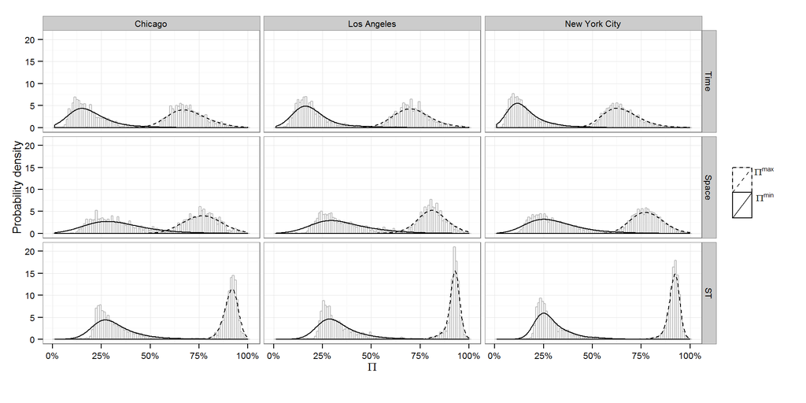

So far the predictability has bee determined. We find that for all the three study sites, predictability is about [15%, 65%] under temporal condition, [25%, 75%] under spatial condition, and [25%, 90%] under spatiotemporal condition.

Put into simple words these findings can be interpreted as follows: by considering spatiotemporal contextual information any prediction algorithm will at least make around 25% correct predictions, simply because the dataset inevitably causes this number. In turn, the same algorithm can be tuned up to a maximum value of 90%. The remaining information (i.e. the missing 10%) is not feasible due to inherent contained uncertainties. Hence, if for any prediction algorithm a prediction accuracy of 30% is being stated, it means that besides the inherited 25% regularity in users check-in behaviour, the algorithm is actually responsible for the remaining 5% gain in accuracy (which would not exactly be a good value). Furthermore, we would also know that there is still much room left for this algorithm to improve its accuracy.

A follow-up question that occurs naturally will then be: *How can one achieve the improvements?* We assume that the precision of prediction is not equal across different kinds of contextual conditions. Instead, the overall precision is to some degree a result of neutralization (some conditions contribute positively; some others might lower the achieved precision). If the variation patterns of predictability underlying different conditions could be revealed, one might gain better knowledge on how to improve some algorithm. This information will be revealed in the following.

#### 3. Variation patterns of predictability

The variation patterns of predictability will be observed from three perspectives: individual, temporal and spatial. We will observe the variation between *predictability* and *the check-in frequency* under each perspective. And *predictability* is observed with three related quantities: $\Pi_{ST}^{max}$,$\Pi_{ST}^{min}$,$\Pi_{ST}^{delta}$.

##### 3.1. Individual perspective

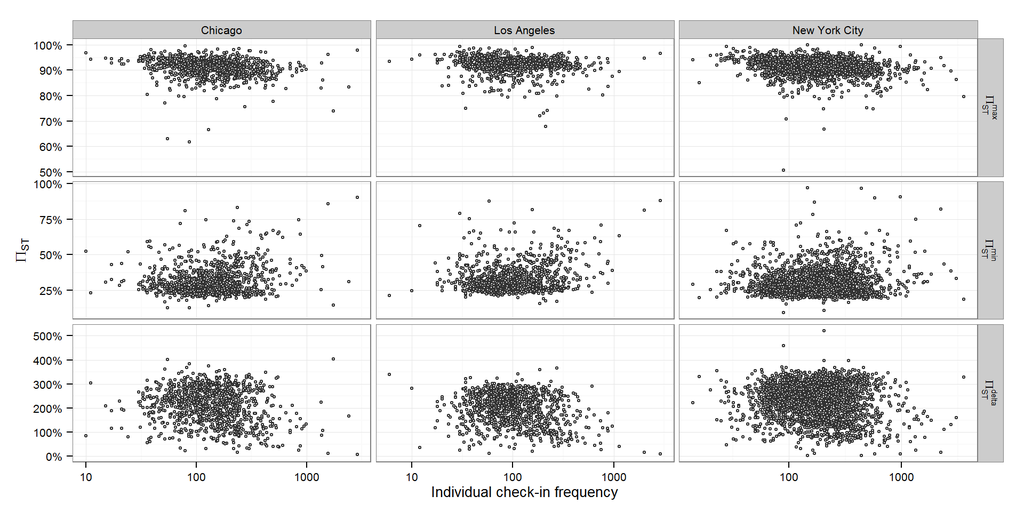

To explain the dispersed nature of the scatterplots in this figure:

- Hypothesis A: Foursquare users might show some similar check-in patterns, regardless of how frequently they are actually using the service. If this is true, it would be quite reasonable to leverage the “collective wisdom” under certain spatiotemporal contexts to predict the behaviour of the inactive users or even new users.
- Hypothesis B: the more active users might provide more information from which to be learned, which is good for the purpose of predicting. However, their activities tend to be more dynamic, which increases the challenge in predicting. Thus the final dispersed distribution could result from both perspectives.

Either way, this figure shows that the **common practice of filtering inactive users is not quite efficient for improving the overall performance of a prediction algorithm**.

##### 3.2. Temporal perspective

**a. correlation**

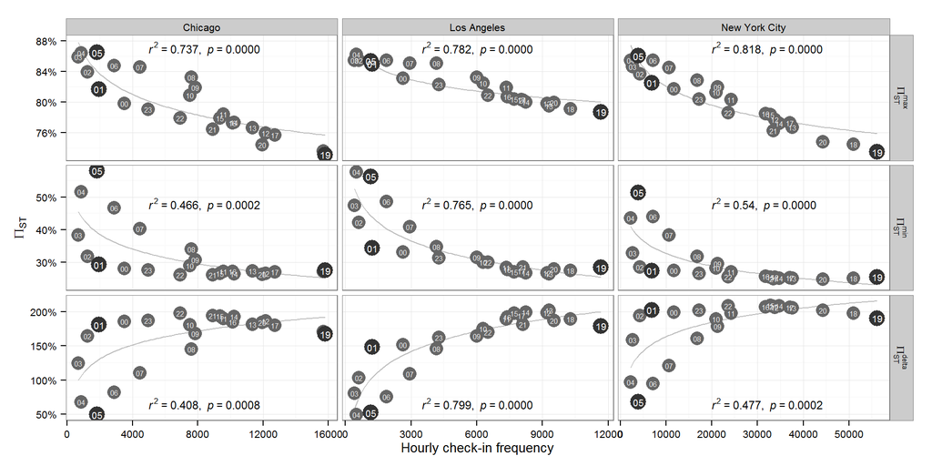

The negative correlations in the upper six subplots suggest that **busier hourly slots provide poorer initial prediction accuracy**. In other words: these slots still provide plenty of room for refining the prediction accuracy. Additionally, the positive correlations shown in the lower three subplots suggest that busier hourly slots also provide stronger leverage effects with respect to improving algorithms. Both of these aspects indicate that focusing on the busy time slots can help to diagnose and improve a prediction algorithm both effectively and efficiently.

**b. histogram/density**

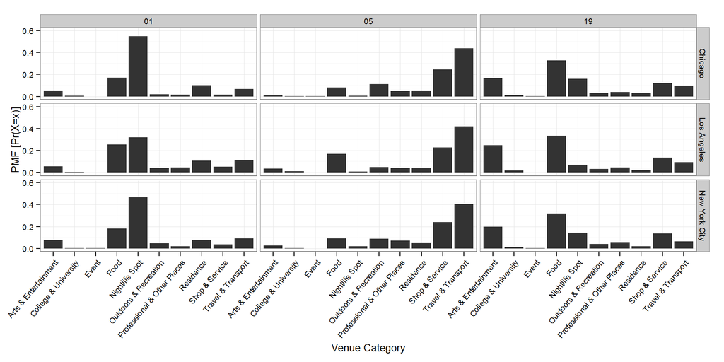

According to the figure above, the reason for **higher predictability in less busy hours could be related to simpler temporal semantics**. In 1 am and 5 am, the users rarely check in at venues of categories other than Nightlife Spot and Travel and Transport. Especially, with the majority checking in at Travel and Transport venues, the predictability in 5 am is extremely high, while the room for improvements is quite narrow. In other words: if the users just check in at a limited number of venue types it is quite likely to achieve precise predictions. In contrast, in the busy hours users tend to pursue much more diverse activities and the temporal semantics are much more complex for predictions.

Therefore, the indication here is that **more effort should be invested in further enriching the busy hours with more detailed contextual information**. In contrast, the predictions for hours showing low activity rates might be rather accurate by just simply considering temporal contextual information. Improving the prediction accuracy for these hourly slots is not worth the effort. Fortunately, the busy hours come with a much richer wealth of data to learn from; therefore it is also practical to shift the focus to these busy time slots only.

##### 3.3. Spatial perspective

**a. correlation**

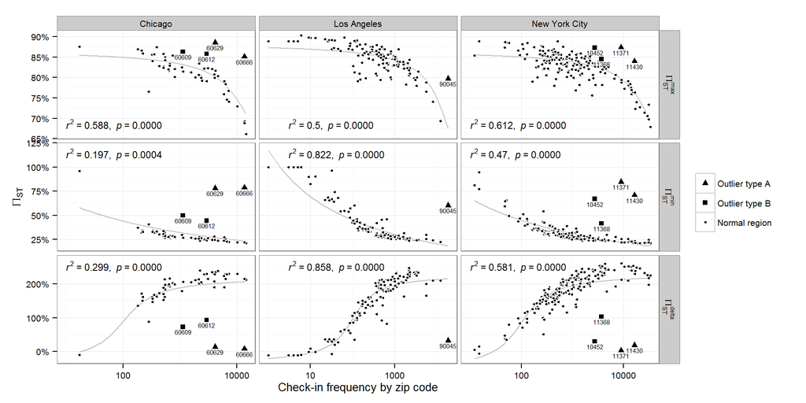

The revealed correlations exhibit quite similar patterns to that of the temporal perspective. Therefore, we assume similar underlying reasons to be effective: **the heavily frequented spatial regions also tend to contain complicated semantics because of the complex functions they typically provide. Hence, the initial prediction accuracy is low while the efficiency for improvement is quite high.**

However, compared with the temporal correlations, the spatial correlation figure distinguishes itself by showing several noticeable outliers. In these outlier zip code areas, users are frequently checking in, while the predictability is yet still high. Thus, it would be interesting to further investigate the outliers and find out *why these regions do not follow the general trend*. We further classified the outliers into two categories: A and B. Outliers of type A are located far below or above the general trend line, while outliers of type B tend to reside closer to the general trend line. Hence, it would also be interesting to *reveal the differences between type A and B outliers*.

**b. histogram/density**

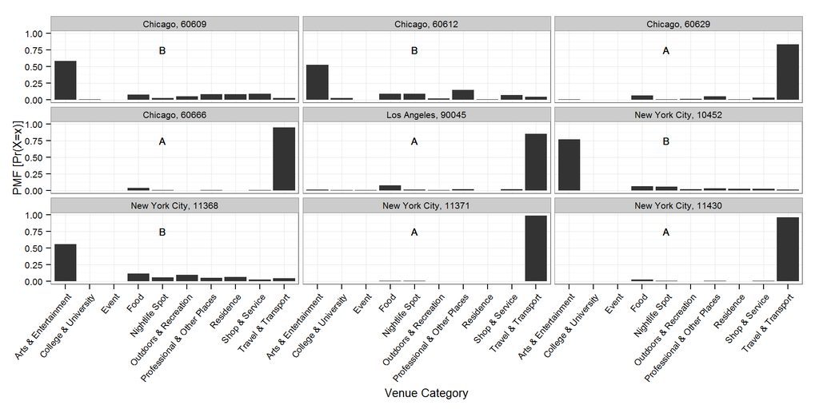

This figure shows that, regardless of the outlier category, all outlier regions are dominated by just one single semantic category each (Travel and Transport in case of type A, Arts and Entertainment in case of type B). However, the dominance of the single category in regions of type A is stronger than that of type B. Hence, these outliers again strengthen our assumptions that were drawn earlier: **simpler semantics result in higher initial prediction accuracy while providing lower improvement efficiency**.

**c. map the outliers**

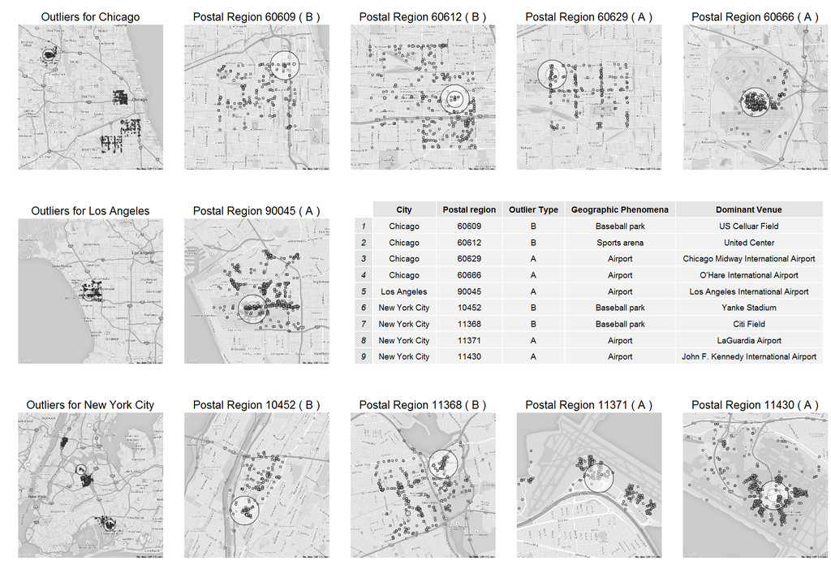

When the outlier instances are all mapped back into geographic space, some interesting facts about the differences between type A and B outliers can be noticed. It is found that each outlier region of type A contains a large airport. In contrast, each outlier region of type B comprises a large sports stadium (see the table in the centre). The figure shows **how tremendously certain types of venues can impact humans check-in behaviour**.

It is supposable that **the dominance of some venue types is a general phenomenon**. That is, we can expect international airports to attract an enormous number of check-ins in most cities, even beyond our study sites. In contrast, **the dominance of some other types of venues might be explicitly local effects; and can therefore not be generalized to a universal viewpoint as easily**. Baseball, for example, is one of the most popular sports in the United States. Therefore, baseball parks strongly impact humans check-in behaviour. Compared to New York City, the inhabitants of Chicago obviously also show a great passion on basketball. Therefore the United Center, which is the home to the *Chicago Bulls* of the National Basketball Association (NBA), dominates the check-in behaviour in the corresponding zip code area.